# RegressionClassProject

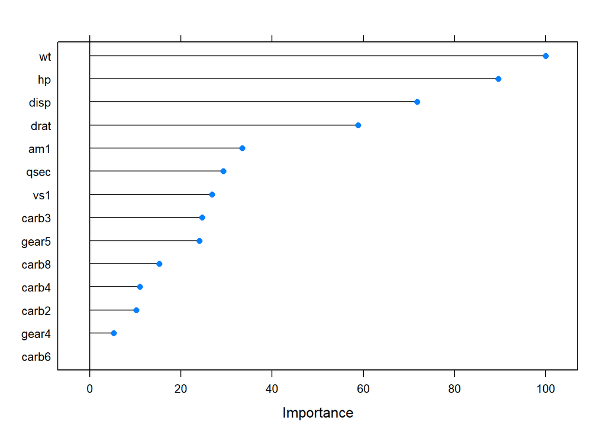

```r
plot(varImp(lm, scale=T))
```

```r
summary(lm$finalModel)
```

```
##
## Call:
## lm(formula = .outcome ~ ., data = dat)
##
## Residuals:
##     Min      1Q  Median      3Q     Max
## -3.1897 -1.3843 -0.3634  0.9201  4.6548
##
## Coefficients:
##             Estimate Std. Error t value Pr(>|t|)
## (Intercept) 12.87276   15.43382   0.834    0.416
## disp         0.03120    0.02420   1.289    0.215
## hp          -0.04916    0.03139  -1.566    0.136
## drat         2.39306    2.19773   1.089    0.291
## wt          -3.89980    2.25665  -1.728    0.102
## qsec         0.52619    0.83550   0.630    0.537
## vs1          1.52262    2.57613   0.591    0.562
## am1          1.95166    2.80814   0.695    0.496
## gear4        0.88681    3.45338   0.257    0.800
## gear5        1.97540    3.60004   0.549    0.590
## carb2       -0.75477    2.25913  -0.334    0.742
## carb3        2.08122    3.72838   0.558    0.584
## carb4       -1.30096    3.76183  -0.346    0.734
## carb6        0.96288    5.50575   0.175    0.863
## carb8        3.04608    7.39745   0.412    0.686
##
## Residual standard error: 2.779 on 17 degrees of freedom
## Multiple R-squared:  0.8834, Adjusted R-squared:  0.7873
## F-statistic: 9.197 on 14 and 17 DF,  p-value: 2.359e-05
```

```r
ridge <- train(mpg~., datamtcars.subset,
               method='glmnet',
               tuneGrid=expand.grid(alpha=0, lambda=seq(3,4,length=5)),
               trControl=custom)
summary(ridge$finalModel)
```

```
##             Length Class      Mode
## a0           100   -none-     numeric
## beta        1400   dgCMatrix  S4
## df           100   -none-     numeric
## dim            2   -none-     numeric
## lambda       100   -none-     numeric
## dev.ratio    100   -none-     numeric
## nulldev        1   -none-     numeric
## npasses        1   -none-     numeric
## jerr           1   -none-     numeric
## offset         1   -none-     logical
## call           5   -none-     call
## nobs           1   -none-     numeric
## lambdaOpt      1   -none-     numeric
## xNames        14   -none-     character
## problemType    1   -none-     character
## tuneValue      2   data.frame list
## obsLevels      1   -none-     logical
## param          0   -none-     list
```

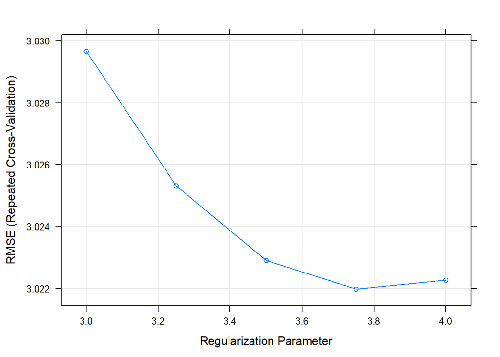

```r
# Plot Results and examine model
plot(ridge) #Examine how lamda impacts the model and may be tweek the breaks up in the model based on this
```

```r
ridge #for model summary numerically
```

```
## glmnet
##
## 32 samples
##  9 predictor
##
## No pre-processing
## Resampling: Cross-Validated (3 fold, repeated 2 times)
## Summary of sample sizes: 22, 21, 21, 22, 20, 22, ...
## Resampling results across tuning parameters:
##
##   lambda  RMSE      Rsquared   MAE
##   3.00    3.029661  0.7839217  2.428396
##   3.25    3.025317  0.7859290  2.423736
##   3.50    3.022897  0.7876445  2.420017
##   3.75    3.021966  0.7891398  2.417018
##   4.00    3.022258  0.7904544  2.415105
##
## Tuning parameter 'alpha' was held constant at a value of 0
## RMSE was used to select the optimal model using the smallest value.
## The final values used for the model were alpha = 0 and lambda = 3.75.
```

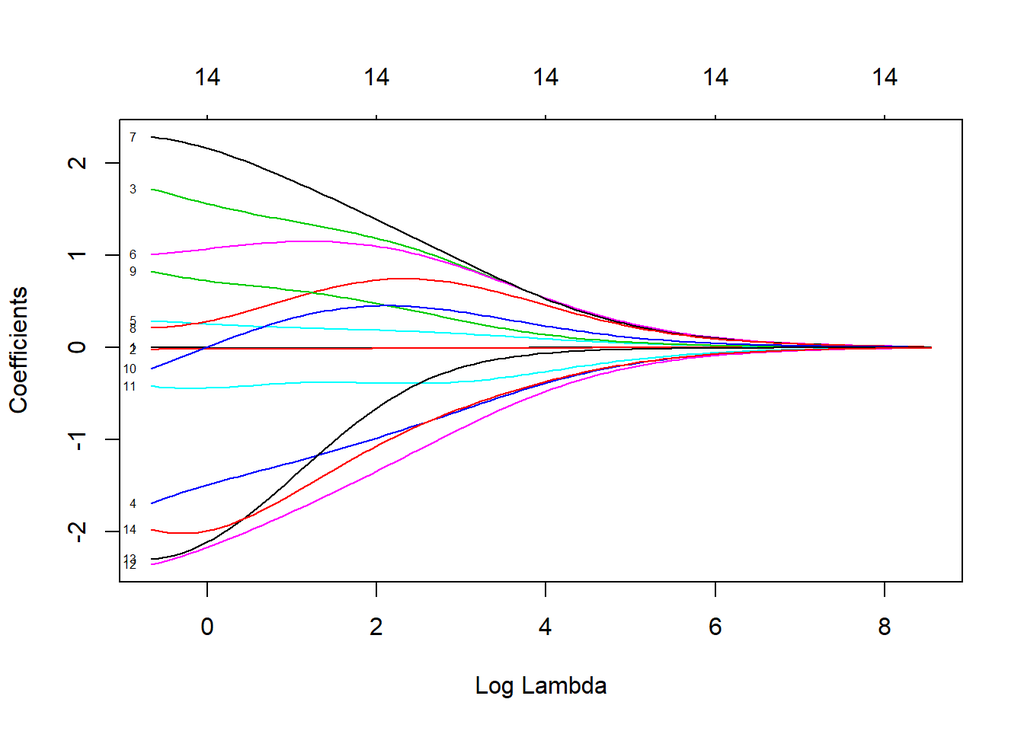

```r
plot(ridge$finalModel, xvar = "lambda", label = T)
```

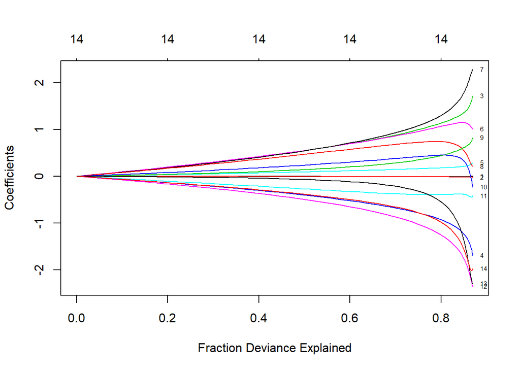

```r
plot(ridge$finalModel, xvar = 'dev', label=T) # how much of the data variance is explained
```

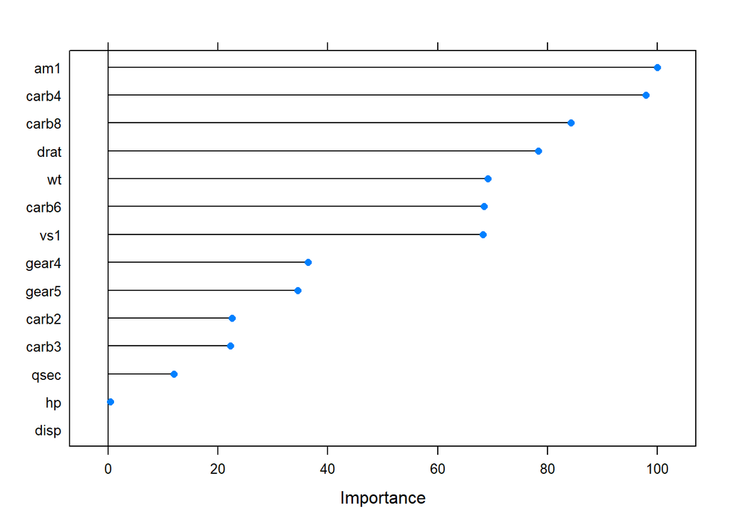

```r
plot(varImp(ridge, scale=T)) # variable relative importance
```

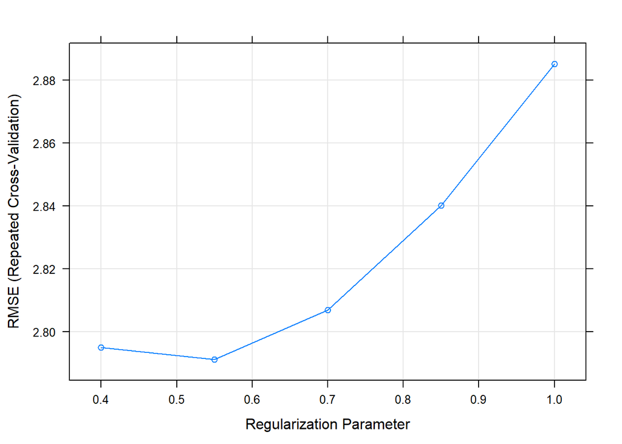

```r
# Lasso Regression
set.seed(1234)
lasso <- train(mpg~., datamtcars.subset,
               method='glmnet',
               tuneGrid=expand.grid(alpha=1, lambda=seq(0.4,1,length=5)),
               trControl=custom)

# Plot Results and examine
plot(lasso)
```

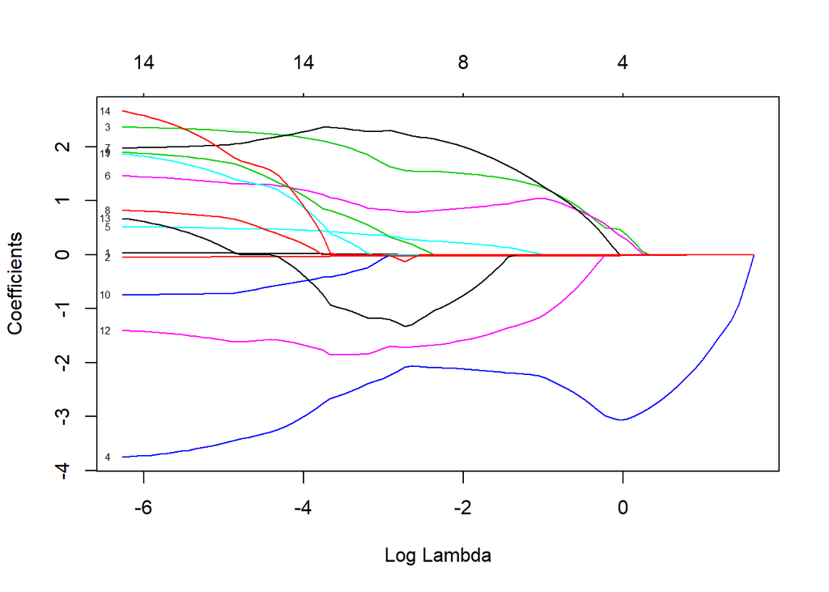

```r
plot(lasso$finalModel, xvar = 'lambda', label=T)
```

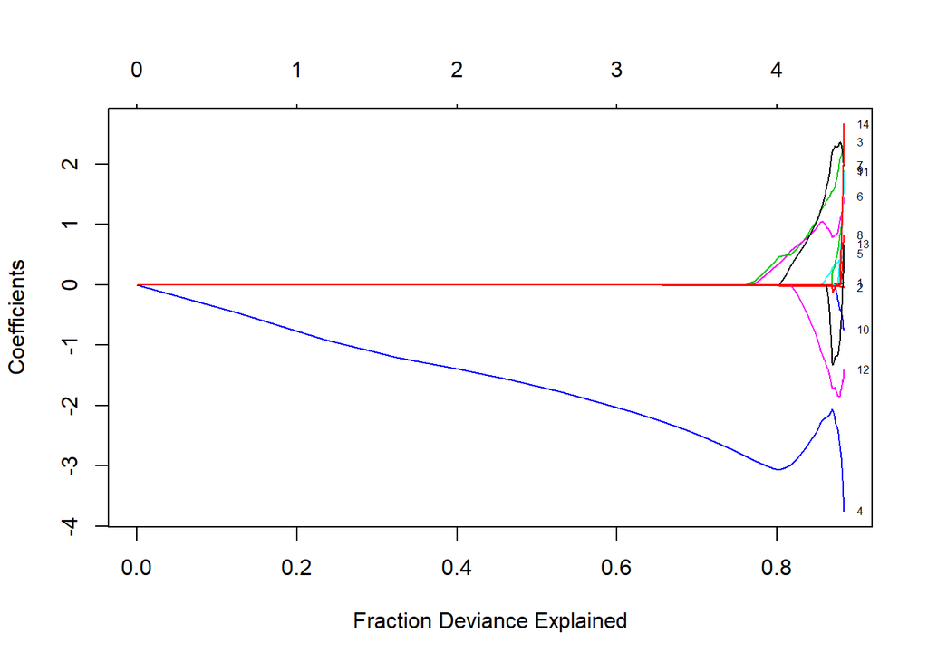

```r
plot(lasso$finalModel, xvar = 'dev', label=T)
```

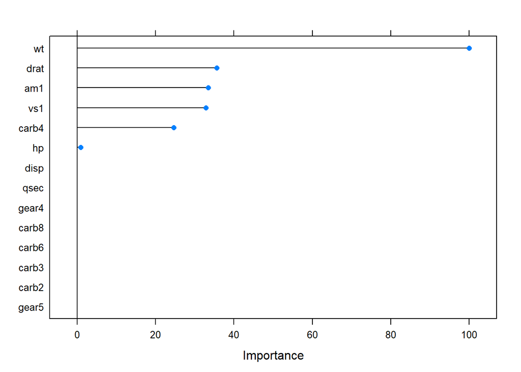

```r
# notice the number of variables that are needed to explain
# the data variability.
plot(varImp(lasso, scale=T)) # checking the variables relative importance
```

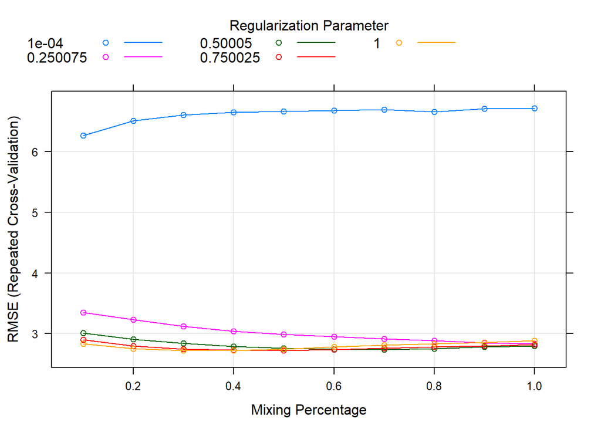

```r
# Elastic Net Regression
# IT is essentially a mix of ridge and lasso
set.seed(1234)
en <- train(mpg~., datamtcars.subset,
            method='glmnet',
            tuneGrid=expand.grid(alpha=seq(0.1,1,length=10), lambda=seq(0.0001,1,length=5)),
            trControl=custom)

# Plot Results
plot(en)
```

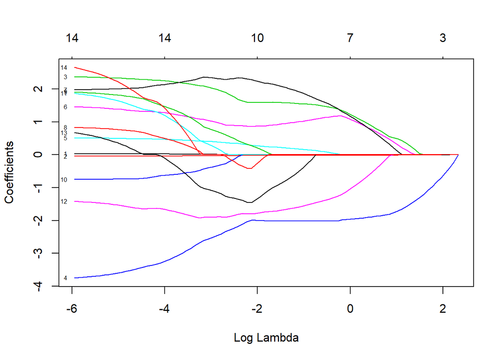

```r
plot(en$finalModel, xvar = 'lambda', label=T)
```

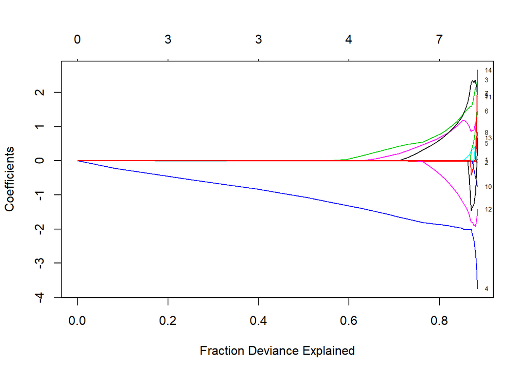

```r
plot(en$finalModel, xvar = 'dev', label=T)
```

```r
# Compare Models.
model_list <- list(LineraModel=lm,Ridge=ridge,Lassso=lasso,
                   ElasticNet=en) #create list of models used
res <- resamples(model_list) #using the resamples in carrot package to compare model
summary(res) #numerical comparison between models. Check the mean value of the mean rsquared
```

```
##
## Call:
## summary.resamples(object = res)
##
## Models: LineraModel, Ridge, Lassso, ElasticNet
## Number of resamples: 6
##
## MAE
##                 Min.  1st Qu.   Median     Mean  3rd Qu.     Max. NA's
## LineraModel 2.426469 2.835883 3.486114 3.953105 4.047433 7.466254    0
## Ridge       1.858853 2.063924 2.539396 2.417018 2.731888 2.862977    0
## Lassso      1.666780 2.123752 2.180514 2.225096 2.323506 2.846763    0
## ElasticNet  1.523257 2.056244 2.190967 2.175113 2.307276 2.788103    0
##
## RMSE
##                 Min.  1st Qu.   Median     Mean  3rd Qu.     Max. NA's
## LineraModel 2.811894 3.389149 4.490057 5.181779 5.886133 9.924996    0
## Ridge       2.429283 2.615424 3.148514 3.021966 3.199663 3.751044    0
## Lassso      1.977563 2.620160 2.856157 2.791072 3.064148 3.381581    0
## ElasticNet  1.792260 2.521580 2.877348 2.718877 2.970037 3.362381    0
##
## Rsquared
##                    Min.   1st Qu.    Median      Mean   3rd Qu.      Max.
## LineraModel 0.003326864 0.4295388 0.6231086 0.5306317 0.7190179 0.8182429
## Ridge       0.556951334 0.7751705 0.8110131 0.7891398 0.8684090 0.9050972
## Lassso      0.748845806 0.8130018 0.8247706 0.8309293 0.8696729 0.8934698
## ElasticNet  0.716800298 0.8192341 0.8342059 0.8393412 0.8956547 0.9204539
##             NA's
## LineraModel    0
## Ridge          0
## Lassso         0
## ElasticNet     0
```

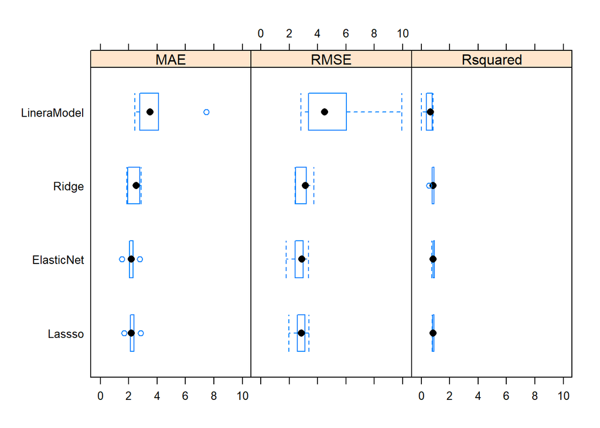

```r
bwplot(res) #plotting the models for comparison
```

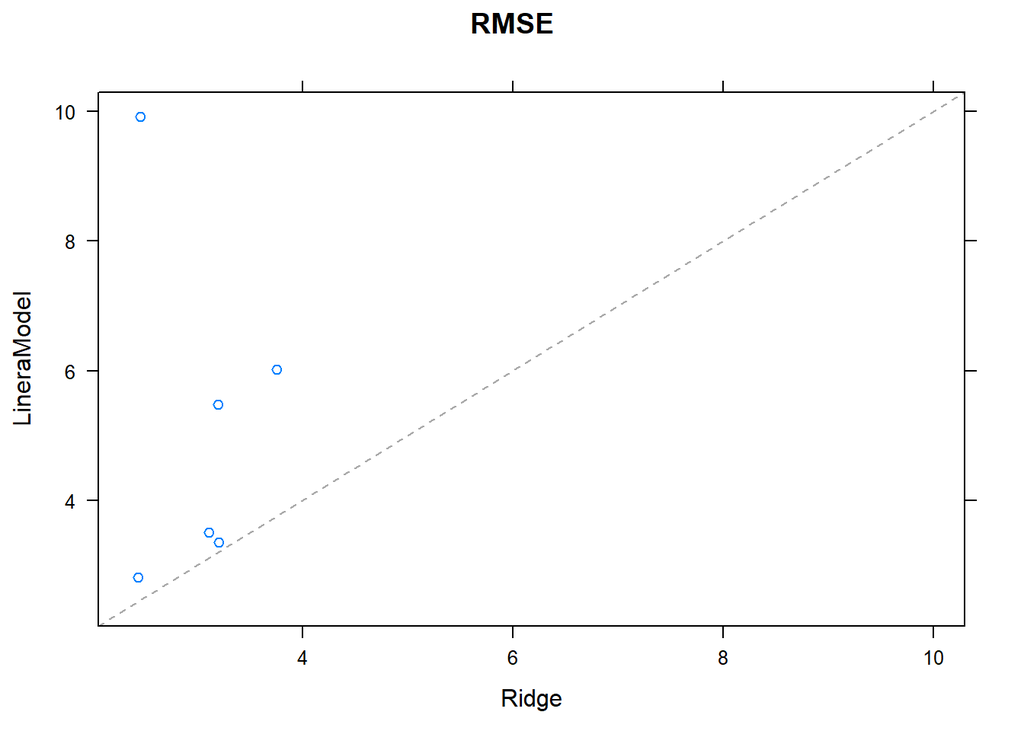

```r
xyplot(res,metric='RMSE')
```

```r
# Best Model
en$bestTune # best values of alpha and lambda
```

```
##    alpha   lambda
## 24   0.5 0.750025
```

```r
best <- en$finalModel #Saving best model
coef(best, s = en$bestTune$lambda) #coefficents of the best model
```

```
## 15 x 1 sparse Matrix of class "dgCMatrix"
##                       1
## (Intercept) 23.80985063
## disp         .
## hp          -0.02433772
## drat         1.40278754
## wt          -2.01802624
## qsec         0.03381991
## vs1          1.17773664
## am1          1.41930640
## gear4        .
## gear5        .
## carb2        .
## carb3        .
## carb4       -1.27168023
## carb6        .
## carb8        .
```

```r
# Elastic net regression is the best mode. let us compare all coefficients for the parameter in the lm and best model
coefficients(summary(lm))[[8]] # lm
```

```
## [1] 1.951657
```

```r
coef(best, s = en$bestTune$lambda)[8] # best lasso
```

```
## [1] 1.419306
```

```r
# both models suggest that the increase in mpg if you go from manual to automatic is 1.4-2 mpg
```

# Simplifying the model based on physics

The previous analysis shows that based on several models fitted, the average saving in mpg is between 1.4 and 2 mpg as we go from manual to automatic transmission. The linear model and elastic net both suggest that mpg increase with transmission type. Let us now try a simple model based on physical sense only. In my experience, using the disp, weight, qsec, hp and transmission are enough to build a physically meaningful model.

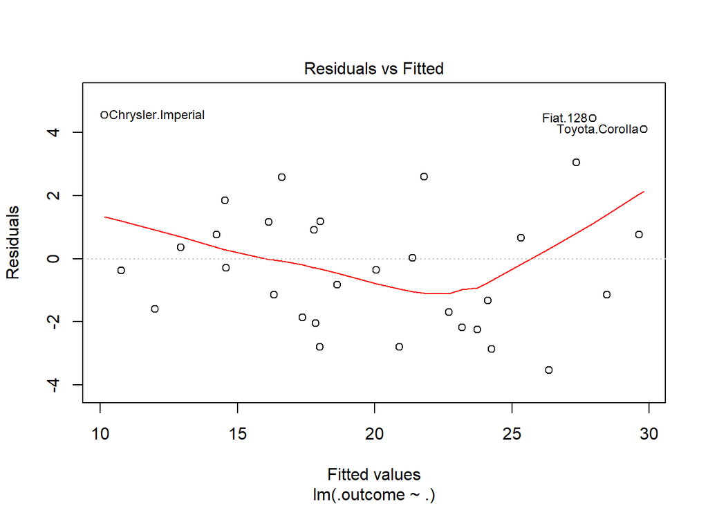

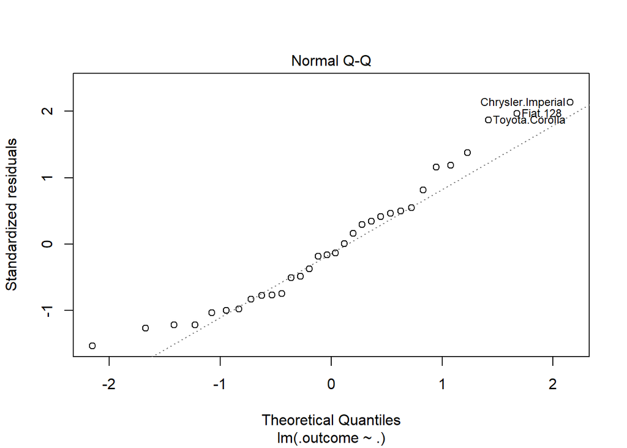

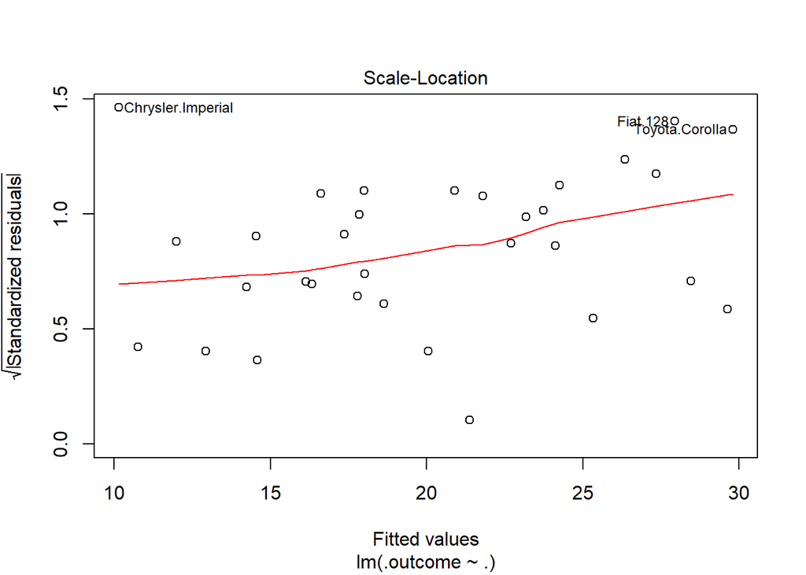

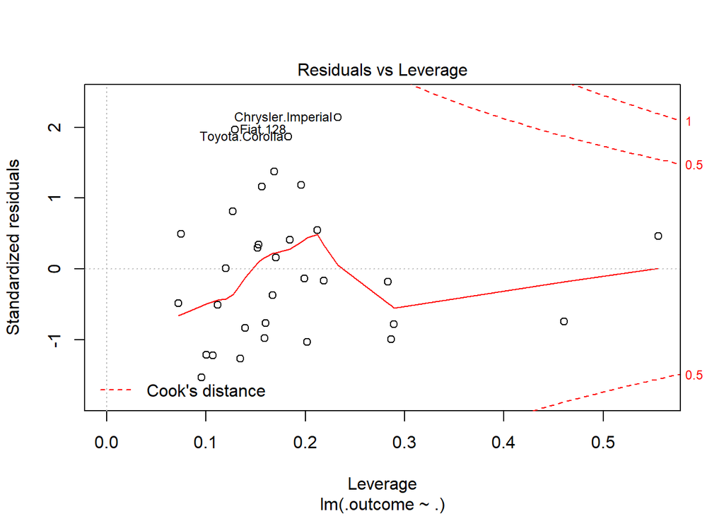

```r
# from an engineering perspective and being a combustion engineer, i beleive that the most important variables are displacement, wt, qsec, hp, am so i will just build a model using that and see how easy it is to interpret the model and feel it.

datamtcars.simple<-select(mtcars,-cyl,-drat,-gear,-carb,-vs)
datamtcars.simple$am<-as.factor(datamtcars.simple$am)

lmSimple <- train(mpg~., datamtcars.simple, method='lm',trControl=custom)

# Results and model examination
plot(lmSimple$finalModel)
```

```r
lmSimple$results
```

```
##   intercept     RMSE  Rsquared      MAE    RMSESD RsquaredSD     MAESD
## 1      TRUE 2.592495 0.8362622 2.153416 0.3495403 0.02274025 0.3156191
```

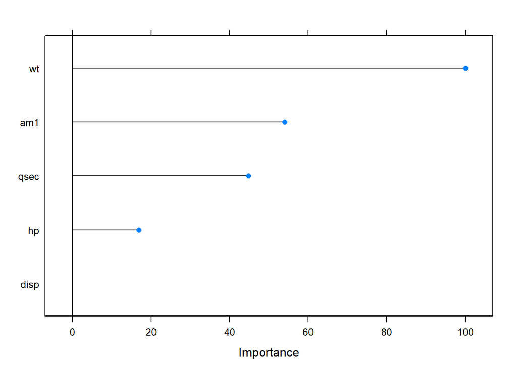

```r
plot(varImp(lmSimple, scale=T))
```

```r
summary(lmSimple$finalModel)
```

```
##
## Call:
## lm(formula = .outcome ~ ., data = dat)
##
## Residuals:
##     Min      1Q  Median      3Q     Max
## -3.5399 -1.7398 -0.3196  1.1676  4.5534
##
## Coefficients:
##             Estimate Std. Error t value Pr(>|t|)
## (Intercept) 14.36190    9.74079   1.474  0.15238
## disp         0.01124    0.01060   1.060  0.29897
## hp          -0.02117    0.01450  -1.460  0.15639
## wt          -4.08433    1.19410  -3.420  0.00208 **
## qsec         1.00690    0.47543   2.118  0.04391 *
## am1          3.47045    1.48578   2.336  0.02749 *
## ---
## Signif. codes:  0 '***' 0.001 '**' 0.01 '*' 0.05 '.' 0.1 ' ' 1
##
## Residual standard error: 2.429 on 26 degrees of freedom
## Multiple R-squared:  0.8637, Adjusted R-squared:  0.8375
## F-statistic: 32.96 on 5 and 26 DF,  p-value: 1.844e-10
```